# excluding_NY_City_medianrentalprice

Thomas Friss

February 14, 2019

## City Median Rental Prices (Excluding New York City)

This is going to explain what I am doing to examine the median rental prices across every city in the Springboard city list except for New York due to the amound of smaller cities that are listed as being in the New York City metropolitan area.

After I feel confident about what I have done with rent and house values outside of New York City then I will examine New York city and figure out how to deal with the data there.

##### Packages Used

```r
library(dplyr)
library(ggplot2)
library(tidyverse)
library(lubridate)
```

Second step, read in the data. This data was acquired from [Zillow](https://www.zillow.com/research/data/). When there go to the Rental Listings section, select Median Rental List Price($) SFR/Condo/co-op.

It is possible that I picked the wrong dataset to work with. There is another area called Rental Values that uses they Zillow Rent Index which is a smoothed measurement of median rental prices. I will have to repeat the code I have made with the other dataset and see if there are any notable differences.

```r
full_rent_df <- read_csv("City_MedianRentalPrice_AllHomes.csv")
```

After this I created a character vector containing the names of the cities I wanted to examine.

```r
city_list <- c("San Francisco","Boston", "Chicago","Los Angeles", "Washington",
               "Seattle","Atlanta", "Austin", "Raleigh", "Durham", "Philadelphia",
               "Dallas", "Denver", "Detroit", "Minneapolis", "Saint Paul", "San Diego",
               "Houston")
```

Next was to pipe my dataset into a filter command.

```r
rent_tibble <- full_rent_df %>% filter(RegionName  %in% city_list)
```

This filter command gives a table of 20 rows and 113 variables. Two of the rows at the end are cities named Washington that are not in the District of Columbia so those need to be removed.

```r
rent_tibble <- rent_tibble[1:18, ]
```

Unfortunately all of the dates have a “X” at the start of the date for reasons that I cannot figure out. Next I removed these characters from the column names. This code does have the drawback of removing any “X” characters from other column names but my dataset does not have any other “X” characters in the column names. If for some reason it did I am not sure what my solution would end up being.

```r
names(rent_tibble) <-gsub("X","", names(rent_tibble))
```

I wanted to change the columns into a datetime format with ymd(). I am still not entirely sure what the practical benefit of it is for my project but it seemed like a good idea at the time. To accomplish this I needed to replace the “.” character with “-” because “-” is more friendly to ymd()

```r
names(rent_tibble) <-gsub("\\.","-", names(rent_tibble))
```

Next I removed 4 columns that did not have any direct application to what I wanted to do. I also wanted to change variables when moving onto the next part.

```r
Z <- rent_tibble[,-c(2:5)]
```

After this I made the data more tidy by gathering the dates to make the data more narrow.

```r
Z<- gather(Z, key = "date", value = "rent", - 1)
```

```r
rent_df<-Z[order(Z$RegionName),]
```

After this the data was ready for some basic visualization.

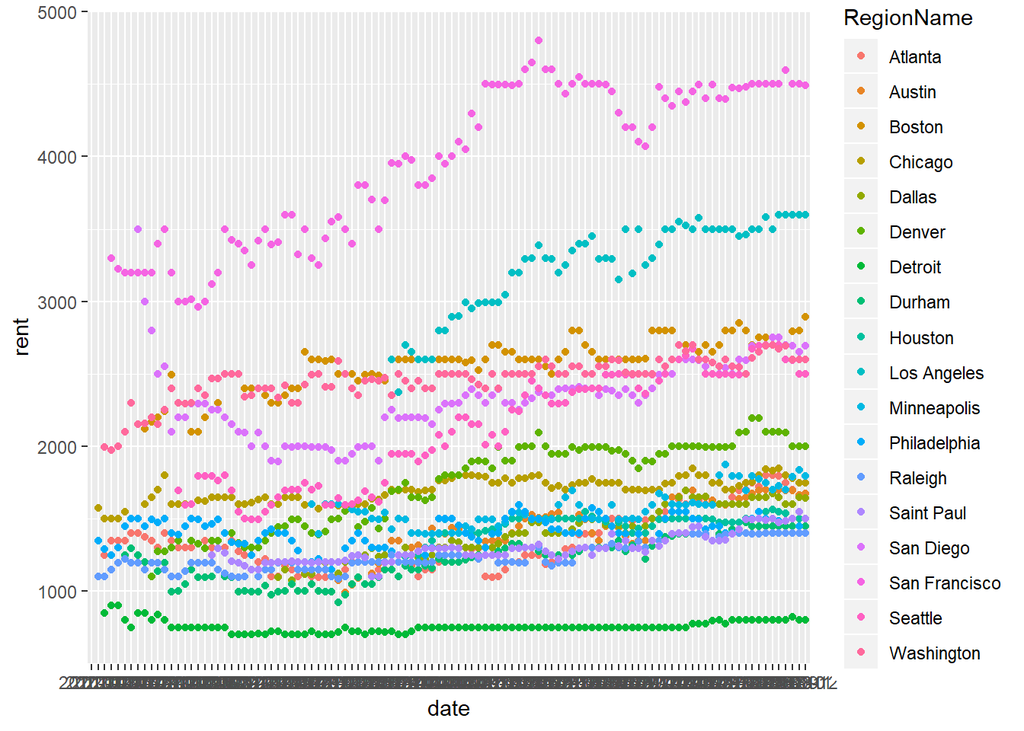

```r
rent_df %>% ggplot(aes(x = date, y = rent, colour = RegionName)) +
  geom_point()
```

The dates are all messed up and I do not remember how to make the text on the x axis have fewer characters on it without reducing the amount of observations being placed on the chart.

A casual visual observation will show that for many of the areas the rent has a weak increase over time but that some areas seem almost horizontal. Due to the amount of cities I used it is somewhat hard to tell some of the different cities apart. I see 4 different colors that could be reasonably described as some shade of purple.

To help fix this I created a csv file that I can use ctrl+f to easily find which row certain cities ended or started on in the data. I am sure there is an easy way to do this in R but ctrl+f is the easiest way to do this that I can think of.

```r
write.csv(rent_df, "excluding_NYC_MedianRentalPrice.csv")
```

With ctrl+f I saw that Denver starts at 541 so I created a graph that only goes to row 540.

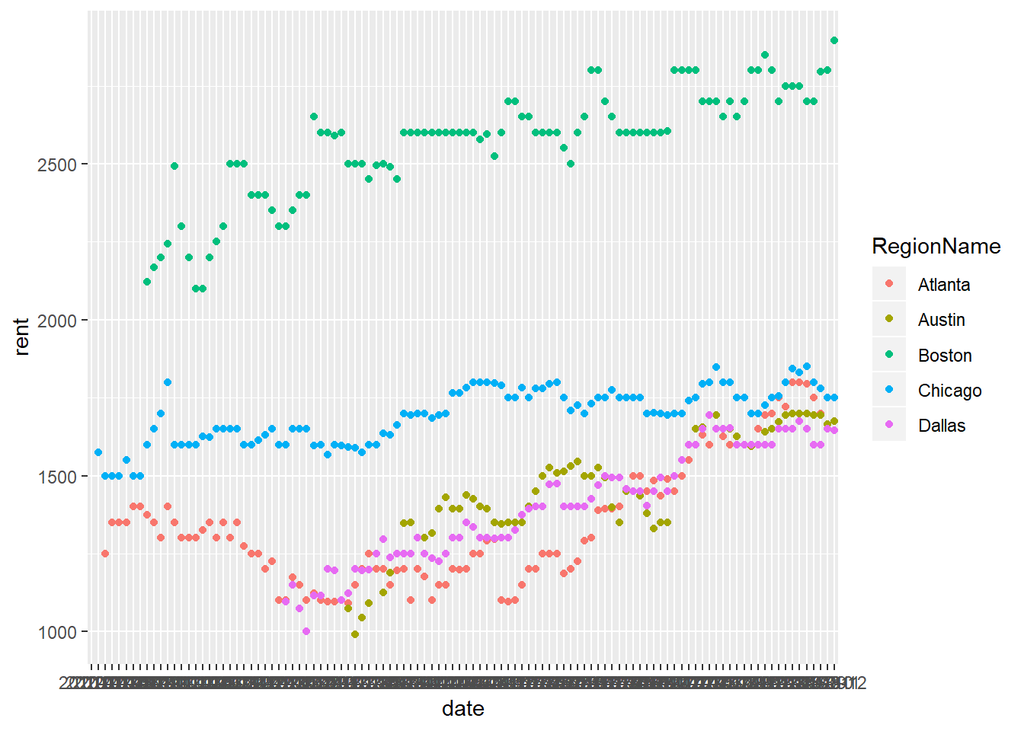

```r
rent_df[c(1:540),] %>% ggplot(aes(x = date, y = rent, colour = RegionName)) +
  geom_point()
```